# Part iA: Predictors (Lexicon: Bing)

INFSCI 2595 Final

Ben Stein

4/27/2022

# About this document

In this document, I perform exploratory data analysis on the variables from the Bing lexicon data.

# Setup

## Libraries and tools

```r
library(tidyverse)
source("./tools.R")
```

## Data

```r
df <- load_project_data() %>%
  select(response_log, outcome_numeric, starts_with("xb"))

df %>% glimpse
```

```
## Rows: 677
## Columns: 10
## $ response_log    <dbl> 0.9624073, 0.1694321, 0.7959862, 1.0030975, 0.3942847,~
## $ outcome_numeric <dbl> 0, 0, 1, 0, 0, 0, 0, 0, 0, 0, 0, 0, 0, 0, 0, 0, 0, 1, ~
## $ xb_01           <dbl> 4.000000, 1.000000, 2.000000, 2.520000, 2.548387, 3.07~
## $ xb_02           <dbl> 4, 1, 2, 11, 6, 6, 10, 12, 9, 10, 8, 10, 10, 8, 6, 10,~
## $ xb_03           <dbl> 4, 1, 2, -6, -1, 1, -4, -4, -2, -4, -2, -2, -2, -4, 1,~
## $ xb_04           <dbl> 1.3333333, 1.0000000, 1.0000000, 0.8950476, 1.2247312,~
## $ xb_05           <dbl> 1.3333333, 1.0000000, 1.0000000, -2.0000000, -0.500000~
## $ xb_06           <dbl> 1.333333, 1.000000, 1.000000, 4.000000, 4.000000, 3.00~
## $ xb_07           <dbl> 4.000000, 1.000000, 2.000000, 1.933333, 1.967742, 1.71~
## $ xb_08           <dbl> -1.00000000, 1.00000000, 0.00000000, -0.08000000, 0.35~
```

# Distributions

Let’s look at the distributions of the variables first.

```r
df %>%
  select(starts_with("xb")) %>%
  summary
```

```
##      xb_01            xb_02            xb_03            xb_04
##  Min.   :-4.000   Min.   :-4.000   Min.   :-7.000   Min.   :-2.000
##  1st Qu.: 2.333   1st Qu.: 3.000   1st Qu.:-1.000   1st Qu.: 0.850
##  Median : 3.250   Median : 6.000   Median : 1.000   Median : 1.138
##  Mean   : 3.377   Mean   : 5.749   Mean   : 1.217   Mean   : 1.153
##  3rd Qu.: 4.250   3rd Qu.: 8.000   3rd Qu.: 3.000   3rd Qu.: 1.428
##  Max.   :14.000   Max.   :15.000   Max.   :14.000   Max.   : 5.000
##      xb_05             xb_06            xb_07            xb_08
##  Min.   :-3.0000   Min.   :-2.000   Min.   :-1.000   Min.   :-4.0000
##  1st Qu.:-0.3333   1st Qu.: 1.200   1st Qu.: 1.667   1st Qu.:-0.2500
##  Median : 0.4000   Median : 2.000   Median : 2.000   Median : 0.2051
##  Mean   : 0.4079   Mean   : 2.107   Mean   : 2.097   Mean   : 0.2124
##  3rd Qu.: 1.0000   3rd Qu.: 3.000   3rd Qu.: 2.500   3rd Qu.: 1.0000
##  Max.   : 5.0000   Max.   : 9.000   Max.   : 7.000   Max.   : 5.0000
```

Like some of the other continuous sentiment variable groups, this group varies in scale, so centering and scaling is likely wise.

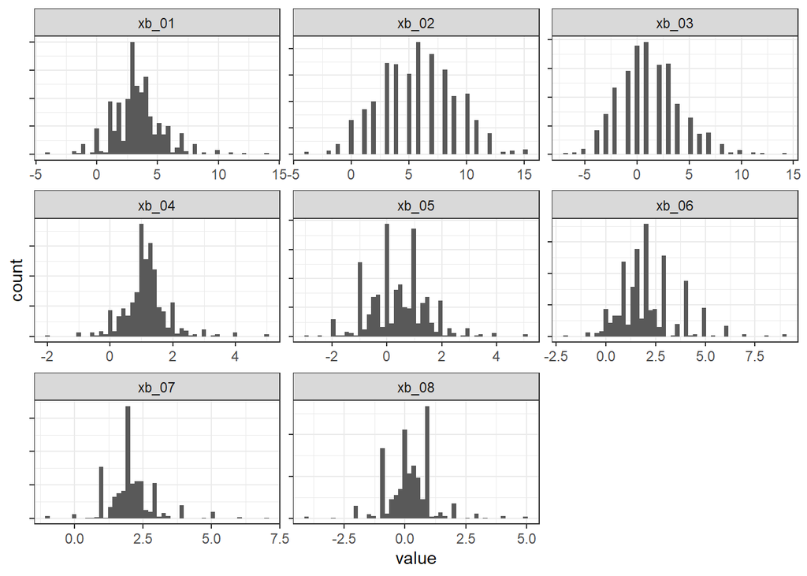

```r
visualize_distributions(df, "xb")
```

Similar to previous groups, all variables are loosely Gaussian. Again, some are more Gaussian than others (e.g. `xb_01` through `xb_04`).

## Unique values

As I worked with each group of continuous predictors, I noticed that some seem to have more unique values than others. Let’s quantify that:

```r
df %>%
  select(starts_with("xb")) %>%
  pivot_longer(cols = everything()) %>%
  group_by(name) %>%
  unique %>%
  count
```

```
## # A tibble: 8 x 2
## # Groups:   name [8]
##   name      n
##   <chr> <int>
## 1 xb_01   229
## 2 xb_02    19
## 3 xb_03    21
## 4 xb_04   364
## 5 xb_05    59
## 6 xb_06    51
## 7 xb_07   181
## 8 xb_08   187
```

# Correlation within the group

Let’s see if any of these inputs are correlated with one another or with the response variable.

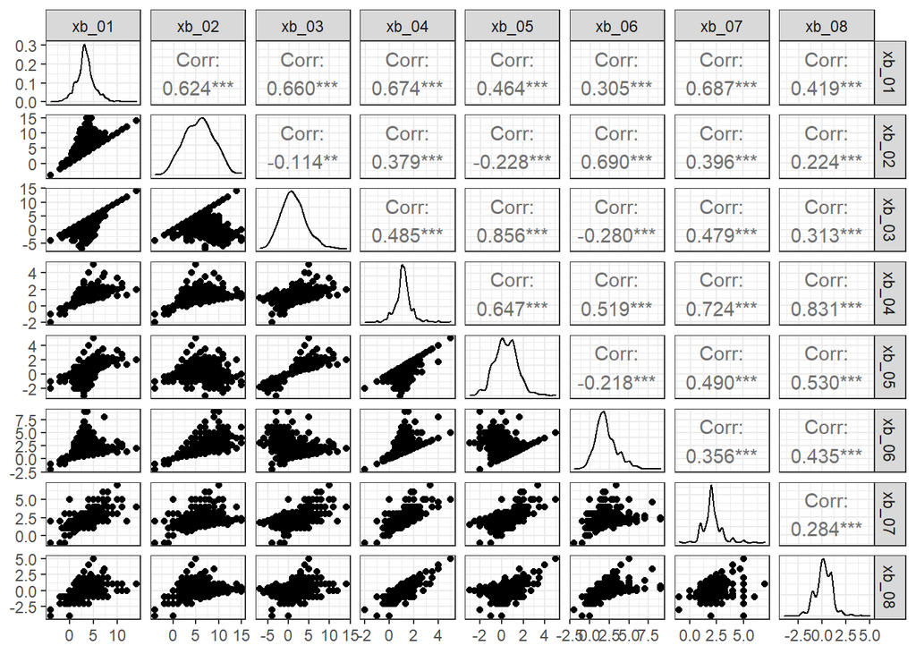

```r
visualize_correlations(df, "xb")
```

Like the AFINN lexicon, there are clear correlations between some of the variables within the group (`xb_01`, for example, is correlated with most other features).

# Relationship to target variables

## The continuous `response` variable

Note that I log-transformed response since that’s what I’ll be predicting anyway.

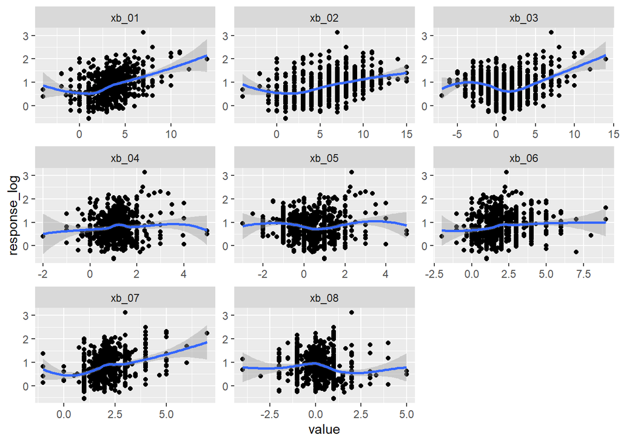

```r
df %>%
  pivot_longer(cols = starts_with("xb")) %>%
  ggplot(mapping = aes(x = value, y = response_log)) +
  geom_point() +
  geom_smooth(formula = y ~ x, method = "loess") +
  facet_wrap(~ name, scales = "free")
```

These loess lines have a bit more personality than the ones we saw in the distributions of the AFINN lexicon variables. The variables are somewhat linear, but may benefit from a “folded” version of linear like splines.

## The `outcome` classification target

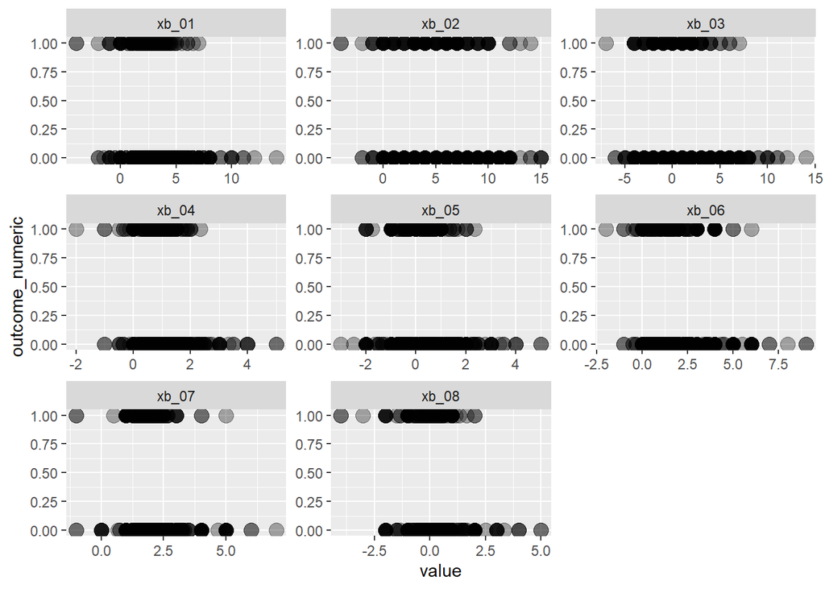

```r
df %>%
  select(-response_log) %>%
  pivot_longer(cols = starts_with("xb")) %>%
  ggplot(mapping = aes(x = value, y = outcome_numeric)) +
  geom_point(size = 4, alpha = .33) +
  facet_wrap(~ name, scales = "free")
```

Like the AFINN lexicon, it’s unclear how this group relates to the outcome. In some cases (e.g. inputs 1, 6, 8), low values of the predictor seem to increase the probability of an event somewhat, but no relationship seems strong.